# 第14・15回 事前学習

作者

J22069 野倉悠正

公開

2026年7月27日

## 7月中のやること

- データベースサーバー（Flask）にフロントエンドを配信する機能の追加
- バックエンドをDockerイメージにするためのファイルを作成
- GitHub Actionsで自動デプロイワークフローを作成
- Gunicornを起動するSystemdユニットを作成
- フロントエンドに生徒用ファイルの変更内容が反映されるように改良
- フロントエンドに生徒用ファイルをプレビューする機能の追加
- フロントエンドに修了証を表示させる機能の追加
- フロントエンドをビルドし、サーバーに配置
- ゼミサーバーのApacheを`www.sekilab.org/sakaki-map/`で配信されるように変更
- 生徒・保護者用のマニュアルを作成
- 「さかき思い出マップ」で変更した内容を「信州おまつりナビ」に反映
- ネイティブアプリへの変更の可用性の再調査・検討

# 1 第14回

## 1.1 ゼミサーバーのApacheを`www.sekilab.org/sakaki-map/`で配信されるように変更

**ノート**

第13回までに完了していた内容だが、記載するのを忘れてしまったため今回報告する。

関ゼミのサーバーはApacheが稼働しており、`/etc/apache2/sites-available`にConfigファイルを追加することで設定を変更することが可能である。以下のように`www`サブディレクトリで配信するための`www.conf`を作成した（[第02・03回事前学習](https://yumachin2003.github.io/docs/zemi26/02_03#:~:text=②証明書をApacheに読み込み)も参考のこと）。このディレクトリはシステムディレクトリであり管理者権限が必要なため、`sudo nano /etc/apache2/sites-available/www.conf`として新規書類として作成した。

```
/etc/apache2/sites-available/www.conf
```

```
<VirtualHost *:80>
    ServerName www.sekilab.org
    Redirect permanent / https://www.sekilab.org/
</VirtualHost>

<VirtualHost *:443>
    ServerName www.sekilab.org

    # 将来的にゼミの紹介ページを置く場合、このような書き方になる。
    # DocumentRoot /var/www/sekilab-intro

    SSLEngine on
    SSLCertificateFile /home/j22069yn/shinshu-fesnav/letsencrypt/live/sekilab.org/fullchain.pem
    SSLCertificateKeyFile /home/j22069yn/shinshu-fesnav/letsencrypt/live/sekilab.org/privkey.pem

    RequestHeader set X-Forwarded-Proto "https"
    RequestHeader set X-Forwarded-Port "443"

    <Location /sakaki-map/api>
        ProxyPreserveHost On
        ProxyPass http://localhost:5002/sakaki-map/api
        ProxyPassReverse http://localhost:5002/sakaki-map/api
    </Location>

    <Location /sakaki-map>
        ProxyPreserveHost On
        ProxyPass http://localhost:5002/sakaki-map
        ProxyPassReverse http://localhost:5002/sakaki-map
    </Location>
</VirtualHost>
```

**1**

HTTP(80番)はすべてHTTPSにリダイレクトさせる。

**2**

SSL/TLS通信を有効にする。

**3**

サーバーの公開鍵を含むSSLサーバー証明書のファイルパスを指定する。

**4**

サーバー証明書とペアになる秘密鍵のファイルパスを指定する。

**5**

リバースプロキシを経由してバックエンドにアクセスする際、クライアントがHTTPSで接続してきたことをバックエンドに伝える。これにより、バックエンド側でリダイレクトなどを行う際に正しいプロトコル（https）が使用される。

**6**

同様に、クライアントがアクセスしてきたポート（443）をバックエンドに伝える。

**7**

`/sakaki-map/api` にアクセスが来た場合の設定を定義する。

**8**

クライアントが要求した元の `Host` ヘッダをバックエンドにそのまま転送する。

**9**

`/sakaki-map/api` へのリクエストを、バックエンドである `http://localhost:5002/sakaki-map/api` に転送（リバースプロキシ）する。

**10**

バックエンドから返されたHTTPレスポンスヘッダ（`Location`など）に含まれる内部のURLを、クライアント側から見えるURLに書き換える。これにより、バックエンドが内部URLでリダイレクトを指示しても、ブラウザからは正常に遷移できる。

**11**

`/sakaki-map` へのアクセスについても、同様に `http://localhost:5002/sakaki-map` へ転送するよう設定する。

**重要**

証明書は「信州おまつりナビ」の時に作成したワイルドカード証明書を利用している。この証明書は`*.sekilab.org`に対して有効であり、`sekilab.org`（サブディレクトリなし）に対しては使えないので、慣例的に`www`をサブディレクトリとしている。

編集完了後、`ctrl-O`で保存。ファイル名を聞かれるが、すでに`www.conf`になっているので`enter`。`ctrl-X`でエディタを閉じる。

次に、Apacheに設定を適用するために、以下のコマンドを実行する。

```
bash
```

```bash
sudo a2ensite www.conf
sudo apachectl configtest
sudo systemctl reload apache2
```

**1**

ConfigファイルをApacheに認識させ、有効化する。`/etc/apache2/sites-enabled/`にシンボリックリンク（ショートカット）が作成される。

**2**

Configファイルの文法チェック。`Syntax OK`と出ていれば問題ない。

## 1.2 前回課題点の修正

### 1.2.1 バックエンドの起動不良

前回、「さかき思い出マップ」をゼミのサーバーにデプロイして本番環境で動かそうとした時に、www.sekilab.org/sakaki-map/ にアクセスしてもサーバーが見つからないという旨のエラーが出ていた。原因を特定するために、以下のコマンドでログを確認した（ログは長いので全文は省略する）。

```
bash
```

```bash
journalctl --user -u sakaki-map.service -f
```

このログをGeminiに読み込ませたところ、

> - `sqlalchemy.exc.OperationalError: (sqlite3.OperationalError) unable to open database file`（データベースのファイルが開けない）
> - `/bin/bash: line 1: exec: nginx: not found`（Nginxの実行ファイルが見つからない）

という2つのエラーが検出された。また、

> - `Error for command "stop": no instance found`（停止するインスタンスが見つからない）

というエラーも検出された。

##### データベースのファイルが開けない問題の修正

この問題は、`/app/instance`フォルダに書き込みの権限がなかったために発生していた。[第13回](https://yumachin2003.github.io/docs/zemi26/13#ワークフローの実行失敗)で行ったように、書き込みの権限を付与した。

```
bash
```

```bash
sudo chmod 777 ~/sakaki-map/instance
```

**ヒント**

777を付与することで、すべてのユーザー（root、所有者、グループ、その他すべて）が読み込み・書き込み・実行の権限を持つことになる。このように各権限を数字で表現することを、**オタクルモード**と呼ぶ。詳しくは、[こちら](https://qiita.com/kentosity/items/814a11d7e0c475bea3d8#オクタルモード-numerical-permission) を参照のこと。

##### Nginxの実行ファイルが見つからない問題の修正

この問題は、サーバーを起動させるスクリプト（`start_server.sh`）がNginxをバックエンドサーバーとして起動しようとしていたため発生していた。修正案としてスクリプトからNginxを削除する方法もあったが、本番環境では、通信の遅れによるサーバーのフリーズを防ぐクッション機能や、画像などの高速配信、セキュリティ対策（暗号化や不正アクセスの防止）を担当するためにリバースプロキシが不可欠である。

しかし、そもそもApptainerのイメージにはNginxが含まれていなかったので、`Dockerfile`でNginxをインストールする形に変更した。

```
sakaki-map/backend/dockerfile
```

```
FROM python:3.13-slim

# コンパイルに必要なパッケージをインストール
RUN apt-get update && apt-get install -y \
    gcc \
    python3-dev \
    libffi-dev \
    libssl-dev \
    nginx \
    && rm -rf /var/lib/apt/lists/*

# コンテナ内の作業ディレクトリを設定
WORKDIR /app

# pipenvとGunicornをインストール
RUN pip install pipenv gunicorn

# 依存関係ファイルをコピーし、システム全体にインストール
COPY Pipfile Pipfile.lock ./
RUN pipenv install --system --deploy

# アプリケーションのコードとフロントエンドのビルド結果(dist)をすべてコピー
COPY . .

# Flaskアプリケーションが使用する5001番ポートを開放
EXPOSE 5001

# Gunicornを使用してアプリケーションを起動
# アプリケーションの構成に合わせてポート5001にバインドし、app.pyのappオブジェクトを指定
CMD ["gunicorn", "--bind", "0.0.0.0:5001", "--workers", "4", "app:app"]
```

**1**

`apt-get install`コマンドに`nginx`を含めるようにした。

##### 停止するインスタンスが見つからない問題の修正

この問題は、サービスを再起動するたびに「インスタンスを停止させる」処理（`ExecStartPre=-/usr/bin/apptainer instance stop sakaki-map`）が走っているが、そもそも停止すべきインスタンスがない状態でコマンドを叩いてしまっていることで発生していた。これに関しては本当に私のうっかりミスで、本来`~/sakaki-map`で`./start_server.sh`というコマンドで実行するところを、誤って`~/.config/systemd/user/`（Systemサービスのユーザーインスタンスの保存ディレクトリ）上で実行してしまっていたことが原因だった。

再発防止のために、以下のように`WorkingDirectory`を`sakaki-map`に指定した。これにより、どのディレクトリでサーバーを起動させても、`sakaki-map`内で実行されるようになった。

```
.config/systemd/user/sakaki-map.service
```

```
[Unit]
Description=sakaki-map Apptainer Service (User Mode)
After=network.target

[Service]
WorkingDirectory=/home/j22069yn/sakaki-map
ExecStartPre=-/usr/bin/apptainer instance stop sakaki-map
ExecStart=/usr/bin/apptainer exec \
  --bind /home/j22069yn/sakaki-map/dist:/usr/share/nginx/html/sakaki-map:ro \
  --bind /home/j22069yn/sakaki-map/nginx.conf:/etc/nginx/nginx.conf:ro \
  --bind /home/j22069yn/sakaki-map/instance:/app/instance \
  --bind /home/j22069yn/sakaki-map/logs:/app/logs \
  --bind /home/j22069yn/sakaki-map/static/:/app/app/static/ \
  /home/j22069yn/sakaki-map/server.sif \
  /bin/bash -c "mkdir -p /tmp/client_temp /app/logs /app/app/static/uploads && cd /app && gunicorn --bind 127.0.0.1:5001 --workers 1 'app:app' & sleep 5 && exec nginx -g 'daemon off;'"
Restart=always
RestartSec=5

[Install]
WantedBy=default.target
```

**1**

`WorkingDirectory`（作業ファイル）を`sakaki-map`に指定した。

## 1.3 オンデマンドアクセスのためのフロントエンドとデータベースの改良

開発環境での起動が前提だったフロントエンドを改良した。「7月中のやること」でいうと、

- フロントエンドに生徒用ファイルの変更内容が反映されるように改良
- フロントエンドに生徒用ファイルをプレビューする機能の追加
- フロントエンドに修了証を表示させる機能の追加

の3つがこれに当たる。また、これにあたり、データベースの設計も一部変更したので、合わせて記載する。

### 1.3.1 フロントエンドに生徒用ファイルの変更内容が反映されるように改良

教室で生徒に作成してもらった、UI部分の設定を変える`lv1.js`の内容をサーバーのデータベースに反映し、それをサーバーにデプロイしたフロントエンドで反映されるようにした。その上で、誰の書式を反映するかを切り替える名目で、簡易的なログイン機能を実装した。

なお、データベースの操作には、VS Codeの拡張機能である「[SQLite3 Editor](https://marketplace.visualstudio.com/items?itemName=yy0931.vscode-sqlite3-editor)」を利用した。

SQLite3 Editor

[figure not shown]

#### アカウントの作成

生徒４人分のアカウント情報を保存する`accounts`テーブルを作成した。

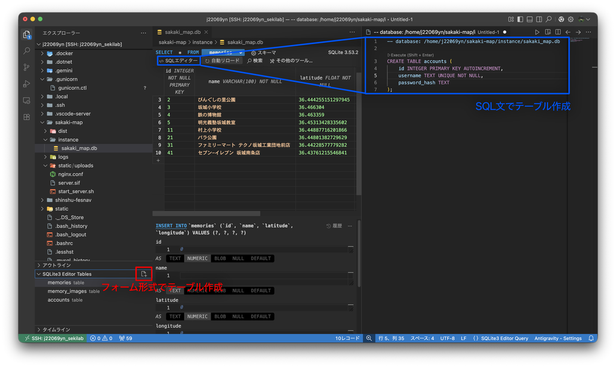

テーブルはフォーム形式で作成する方法や、SQL文を入力して作成する方法がある。

**ヒントパスワードハッシュの生成方法**

アカウント情報は全て手入力の必要があったため、パスワードのハッシュ値はターミナル上で手動生成した（[文字列からワンライナーでハッシュ値を求める - Sig9 Memo v4.0](https://sig9.org/blog/2026/01/02/) を参考にした）。

```
bash
```

```bash
echo -n "password" | openssl dgst -sha256
```

本来インラインにパスワードを直入力するのは、履歴が残るためセキュリティ的によろしくない。しかし今回は簡易的なアカウント機能であり、パスワードも規則的なためインライン入力をしている。

#### `lv1.js`の値をデータベースに保存

上で作成した`accounts`テーブルに、生徒各々の`lv1.js`の変更内容を追加した。

[figure not shown]

これで`accounts`テーブルからログイン時の`lv1.js`を読み込ませることができるようになり、生徒が変更した`lv1.js`の内容を反映させることが可能になった。

#### 「信州おまつりナビ」からログインモーダルを移植

「信州おまつりナビ」のログインモーダル

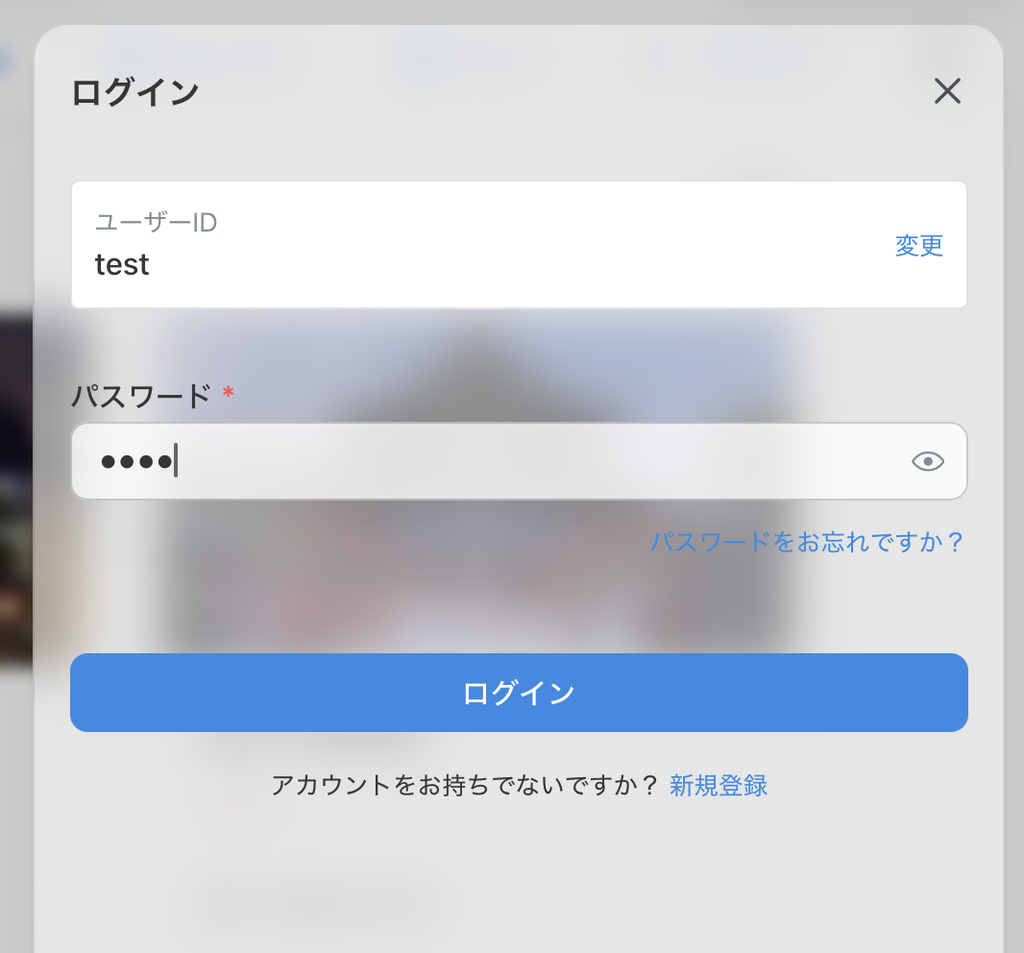

「信州おまつりナビ」で使用しているログインモーダル（右図）を移植した。機能を簡略化するため、新規アカウント作成、ソーシャルログイン、パスキーの機能は省いている。

PC表示

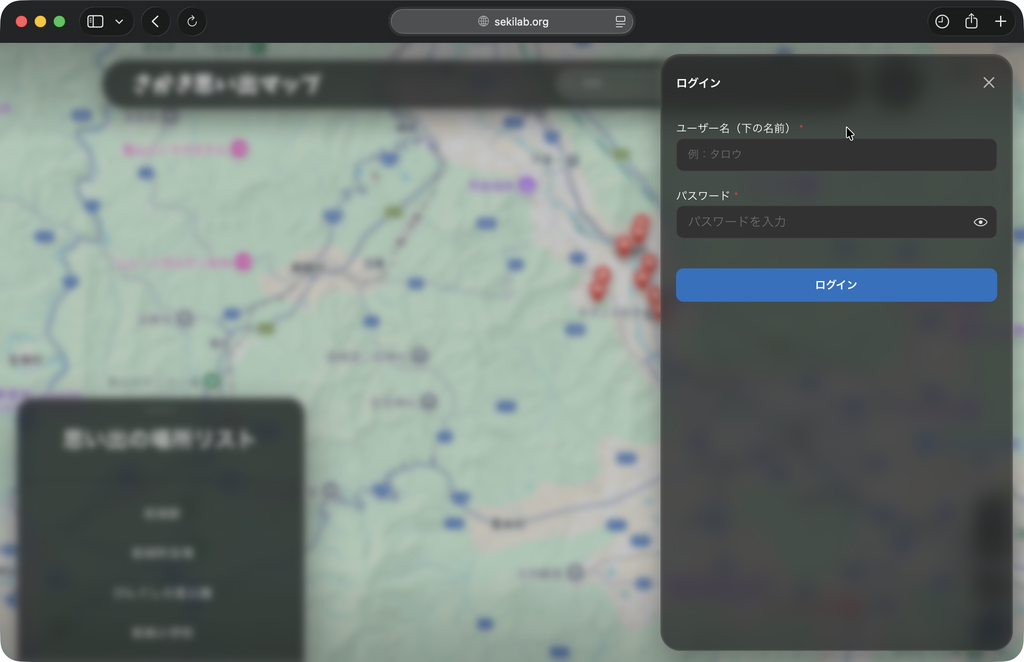

モバイル表示

[figure not shown]

```
sakaki-map/frontend/src/compornents/login.jsx
```

```javascript
import React, { useState } from "react";
import { Drawer, Modal, Text, TextInput, PasswordInput, Button, Stack, Alert } from '@mantine/core';
import { useMediaQuery } from '@mantine/hooks';
import { getApiBaseUrl } from '../App';
import '../css/GlassStyle.css';

export default function Login({ opened, onClose, onLoginSuccess }) {
  const isMobile = useMediaQuery('(max-width: 768px)');
  const [username, setUsername] = useState("");
  const [password, setPassword] = useState("");
  const [loading, setLoading] = useState(false);
  const [error, setError] = useState(null);

  const handleSubmit = async (e) => {
    e.preventDefault();
    setError(null);

    if (!username) {
      setError("ユーザー名を入力してください");
      return;
    }
    if (!password) {
      setError("パスワードを入力してください");
      return;
    }

    setLoading(true);
    try {
      const response = await fetch(`${getApiBaseUrl()}/sakaki-map/api/login`, {
        method: 'POST',
        headers: {
          'Content-Type': 'application/json'
        },
        body: JSON.stringify({ username, password })
      });

      const data = await response.json();

      if (!response.ok) {
        throw new Error(data.error || 'ログインに失敗しました');
      }

      onLoginSuccess(data.user);
      onClose();
    } catch (err) {
      setError(err.message);
    } finally {
      setLoading(false);
    }
  };

  const title = <Text c="var(--glass-text)" fw={700}>ログイン</Text>;

  const formContent = (
    <form onSubmit={handleSubmit}>
      <Stack gap="md">
        {error && <Alert color="red" title="ログインエラー">{error}</Alert>}

        <TextInput
          label="ユーザー名（下の名前）"
          placeholder="例：タロウ"
          value={username}
          onChange={(e) => setUsername(e.currentTarget.value)}
          required
          autoFocus
        />

        <PasswordInput
          label="パスワード"
          placeholder="パスワードを入力"
          value={password}
          onChange={(e) => setPassword(e.currentTarget.value)}
          required
        />

        <Button type="submit" fullWidth loading={loading} mt="md">
          ログイン
        </Button>
      </Stack>
    </form>
  );

  const commonProps = {
    opened,
    onClose,
    title,
    zIndex: 11000, // AppShell(10000)より上に表示
    overlayProps: { backgroundOpacity: 0.2, blur: 4 },
  };

  if (isMobile) {
    return (
      <Modal
        {...commonProps}
        centered
        radius="xl"
        classNames={{ content: 'glass-modal', header: 'glass-modal-header' }}
      >
        {formContent}
      </Modal>
    );
  }

  return (
    <Drawer
      {...commonProps}
      position="right"
      size="sm"
      radius="xl"
      transitionProps={{ transition: 'slide-left', duration: 400 }}
      offset={12}
      classNames={{ content: 'glass-drawer', header: 'glass-drawer-header' }}
    >
      {formContent}
    </Drawer>
  );
}
```

##### ログイン処理部分の解説

ユーザーが入力した`username`と`password`をJSONデータに変換し、バックエンドのログインAPIにPOSTリクエストとして送信している。非同期処理（`async`/`await`）を利用してサーバーからの返答を待機する。

```
JSX
```

```javascript
    try {
      const response = await fetch(`${getApiBaseUrl()}/sakaki-map/api/login`, {
        method: 'POST',
        headers: {
          'Content-Type': 'application/json'
        },
        body: JSON.stringify({ username, password })
      });

      const data = await response.json();

      if (!response.ok) {
        throw new Error(data.error || 'ログインに失敗しました');
      }

      onLoginSuccess(data.user);
      onClose();
    } catch (err) {
      setError(err.message);
    } finally {
      setLoading(false);
    }
```

**1**

**API通信の実行:** `fetch`関数を用いて、バックエンドのログイン用APIにユーザー名とパスワードをPOST送信する。

**2**

**レスポンスデータの取得:** サーバーからのレスポンスをJSON形式として読み込み、`data`変数に格納する。

**3**

**HTTPエラーの判定:** レスポンスのHTTPステータスが正常（`ok`）でなかった場合、エラーを投げて処理を中断する。ここで投げられたエラーは下部の`catch (err)`ブロックで拾われ、`setError`を通じて画面上に赤い警告ダイアログ（`Alert`）として表示される仕組み。

**4**

**ログイン成功時の処理:** ログインに成功した場合、取得したユーザー情報（`data.user`）を、親コンポーネントの`onLoginSuccess`関数へ渡し、ログイン画面を閉じる（`onClose()`）。

**5**

**例外エラーのキャッチ:** ネットワークエラーや③で投げられたエラーをここでキャッチし、画面に表示するため`setError`で状態を更新する。

**6**

**終了処理（ローディング解除）:** 処理の成功・失敗にかかわらず最後に実行され、ボタンなどの「ローディング中」状態を解除する。

###### 描画部分の解説

ログイン画面のポップアップを表示する処理。`opened`プロパティが`true`の場合にモーダルが表示される。「信州おまつりナビ」と同じように、`isMobile`プロパティが`true`の場合（モバイル表示）はモーダルが画面中央に表示され、`false`の場合（PC表示）は右から出現するドロワーが表示される。なお、`isMobile`プロパティは、画面の幅が768px以下の場合に`true`となる。

```
JSX
```

```javascript
  const title = <Text c="var(--glass-text)" fw={700}>ログイン</Text>;

  const formContent = (
    <form onSubmit={handleSubmit}>
      <Stack gap="md">
        {error && <Alert color="red" title="ログインエラー">{error}</Alert>}

        <TextInput
          label="ユーザー名（下の名前）"
          placeholder="例：タロウ"
          value={username}
          onChange={(e) => setUsername(e.currentTarget.value)}
          required
          autoFocus
        />

        <PasswordInput
          label="パスワード"
          placeholder="パスワードを入力"
          value={password}
          onChange={(e) => setPassword(e.currentTarget.value)}
          required
        />

        <Button type="submit" fullWidth loading={loading} mt="md">
          ログイン
        </Button>
      </Stack>
    </form>
  );

  const commonProps = {
    opened,
    onClose,
    title,
    zIndex: 11000,
    overlayProps: { backgroundOpacity: 0.2, blur: 4 },
  };

  if (isMobile) {
    return (
      <Modal
        {...commonProps}
        centered
        radius="xl"
        classNames={{ content: 'glass-modal', header: 'glass-modal-header' }}
      >
        {formContent}
      </Modal>
    );
  }

  return (
    <Drawer
      {...commonProps}
      position="right"
      size="sm"
      radius="xl"
      transitionProps={{ transition: 'slide-left', duration: 400 }}
      offset={12}
      classNames={{ content: 'glass-drawer', header: 'glass-drawer-header' }}
    >
      {formContent}
    </Drawer>
  );
```

**1**

**タイトル表示:** `<Text>`コンポーネントを使って、ダイアログのタイトルに「ログイン」というテキストを表示する。`c="var(--glass-text)"`で、後述する`--glass-text`というCSSカスタムプロパティ（後述）で定義された色（通常は白）を適用し、`fw={700}`で太字にしている。

**2**

**フォーム内容の定義:** 画面に表示するフォームの構造全体を、JSXのコード片として`formContent`変数に保持している。これには、エラーメッセージ表示欄（`Alert`）、ユーザー名入力欄（`TextInput`）、パスワード入力欄（`PasswordInput`）、そして送信ボタン（`Button`）が含まれる。

**3**

**共通プロパティの定義:** `Modal`（モーダル）と`Drawer`（引き出し）の両方で使う共通の設定（表示/非表示の制御、閉じる操作、タイトル、重ね合わせ順序など）を`commonProps`オブジェクトにまとめて、コードの重複を防いでいる。

**4**

**モーダル表示:** スマートフォンなどのモバイル環境では、画面中央に表示される`Modal`を使用する。`{...commonProps}`で共通設定を適用し、`radius="xl"`で角を丸く、`classNames`で後述の`glass-modal`クラスを適用して見た目を統一している。

**5**

**ドロワー表示:** デスクトップ環境などでは、画面右からスライドして出てくる`Drawer`を使用する。`{...commonProps}`で共通設定を適用し、`position="right"`で位置、`size="sm"`で幅、`radius="xl"`、`transitionProps`でアニメーション（右から左へスライド）、`offset`で画面端からの余白などを設定して、見た目を整えている。

### 1.3.2 UI設定を切り替えるマイページを作成

Lv.4で生徒が作成したJSONファイルをアップロードするモーダルとして作成した`StuUpload.jsx`を、エディタ風プレビュー画面を生かして、ログイン後のマイページへと改良した。

使える機能は、

- アカウント情報の閲覧
  - 修了証の閲覧
- データ（思い出）の新規登録
- UI設定（見た目）の編集

であり、それぞれをタブで切り替えられるようにしてある。

「見た目の変更」タブ

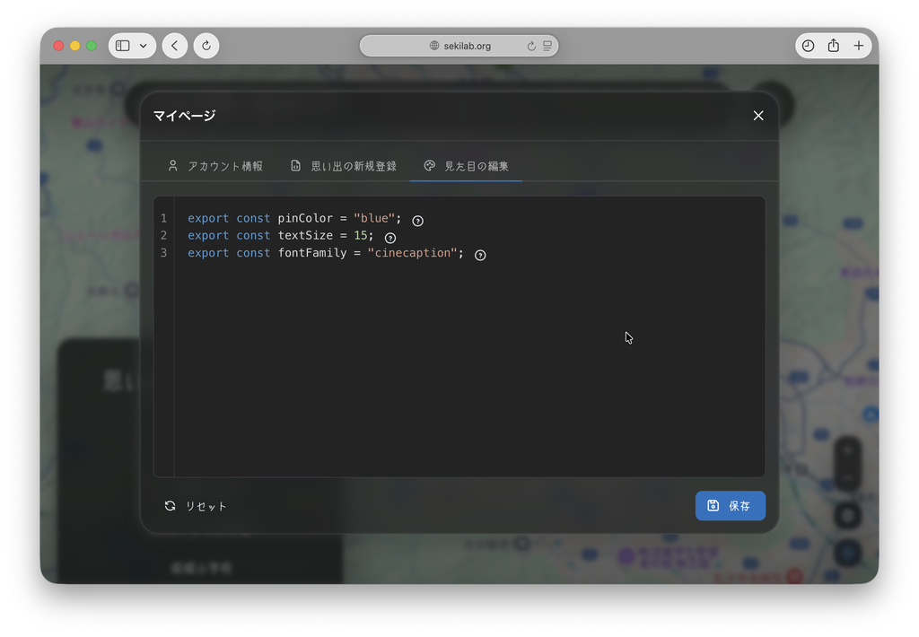

なお、変更前のアップロードモーダルについては、[第04回事前学習](https://yumachin2003.github.io/docs/zemi26/07#:~:text=3%20データ送信機能の設計)から確認可能。

```
sakaki-map/frontend/src/pages/StuUpload.jsx
```

```javascript
import React, { useState, useEffect, useMemo, useRef } from 'react';
import { Modal, Box, Button, Group, Title, Text, Stack, Tooltip, ActionIcon, Tabs } from '@mantine/core';
import { IconSend, IconFileCode, IconUser, IconPalette, IconDeviceFloppy, IconHelpCircle, IconRefresh, IconX } from '@tabler/icons-react';
import hljs from 'highlight.js/lib/core';
import json from 'highlight.js/lib/languages/json';
import javascript from 'highlight.js/lib/languages/javascript';
import 'highlight.js/styles/vs2015.css'; // VS Code風のダークテーマ
import { getApiBaseUrl } from '../App';
import { useLocation, useNavigate } from 'react-router-dom';
import { notifications } from '@mantine/notifications';
import CodeHelp from '../components/CodeHelp';
import copyingCoordinateVideo from '../assets/copying_coodinate.mp4';
import certificateBg from '../assets/certificate_bg.jpg';

hljs.registerLanguage('json', json);
hljs.registerLanguage('javascript', javascript);

export default function MyPage({ opened, onClose, userSettings, setUserSettings, sharedMemories = [] }) {
  const location = useLocation();
  const navigate = useNavigate();

  const getActiveTab = () => {
    if (location.pathname === '/account/register') return 'memory';
    if (location.pathname === '/account/appearance') return 'appearance';
    return 'account';
  };

  const [activeTab, setActiveTab] = useState(getActiveTab());

  useEffect(() => {
    if (opened) {
      setActiveTab(getActiveTab());
    }
  }, [location.pathname, opened]);

  const handleTabChange = (val) => {
    setActiveTab(val);
    if (val === 'memory') navigate('/account/register');
    else if (val === 'appearance') navigate('/account/appearance');
    else navigate('/account');
  };

  // 次の思い出IDをアカウントIDに基づいて生成する関数
  const generateNextMemoryId = (accountId, existingMemories) => {
    if (!accountId) return 100; // 未ログインなどのフォールバック
    const accIdStr = String(accountId);

    // 現在のアカウントIDから始まるIDを持つ思い出を抽出
    const myMemories = existingMemories.filter(m => String(m.id).startsWith(accIdStr));

    if (myMemories.length === 0) {
      return parseInt(accIdStr + "1", 10);
    }

    const maxId = Math.max(...myMemories.map(m => m.id));
    let nextId = maxId + 1;

    // 次のIDがアカウントIDから始まらなくなった場合（例：29 -> 30）、桁を増やす（例：200）
    if (!String(nextId).startsWith(accIdStr)) {
      const newLen = String(maxId).length + 1;
      nextId = parseInt(accIdStr + "0".repeat(newLen - accIdStr.length), 10);
    }

    return nextId;
  };

  // --- 思い出登録用の状態 ---
  const [memoryCode, setMemoryCode] = useState('');
  const [memoryError, setMemoryError] = useState(false);
  const [memoryErrorLine, setMemoryErrorLine] = useState(-1);
  const [isSubmitting, setIsSubmitting] = useState(false);

  const jsonPreRef = useRef(null);
  const jsonLineRef = useRef(null);
  const jsonErrorPreRef = useRef(null);
  const jsonTooltipRef = useRef(null);

  // --- 見た目編集用の状態 ---
  const [appearanceCode, setAppearanceCode] = useState('');
  const [appearanceError, setAppearanceError] = useState('');
  const [appearanceErrorLines, setAppearanceErrorLines] = useState([]);
  const [isSavingSettings, setIsSavingSettings] = useState(false);

  const jsPreRef = useRef(null);
  const jsLineRef = useRef(null);
  const jsErrorPreRef = useRef(null);
  const jsTooltipRef = useRef(null);

  const [activeJsLine, setActiveJsLine] = useState(null);
  const [activeJsonLine, setActiveJsonLine] = useState(null);
  const [isCertModalOpen, setIsCertModalOpen] = useState(false);

  // --- 書式リセット処理 ---
  const handleResetMemory = () => {
    setMemoryCode(`{\n  "name": ,\n  "latitude": ,\n  "longitude": ,\n  "detail": \n}`);
    setMemoryError(false);
    setMemoryErrorLine(-1);
  };

  const handleResetAppearance = () => {
    if (userSettings) {
      setAppearanceCode(`export const pinColor = "${userSettings.pinColor || 'red'}";\nexport const textSize = ${userSettings.textSize || 15};\nexport const fontFamily = "${userSettings.fontFamily || 'sans-serif'}";`);
      setAppearanceError('');
      setAppearanceErrorLines([]);
    }
  };

  // モーダルを開いた時に状態をリセット・初期化
  useEffect(() => {
    if (opened) {
      // 動的に次のIDを計算してテンプレートを作成
      const nextId = generateNextMemoryId(userSettings?.id, sharedMemories);
      const dynamicTemplate = `{
  "name": ,
  "latitude": ,
  "longitude": ,
  "detail":
}`;

      // JSONエディタの初期化
      setMemoryCode(dynamicTemplate);
      setMemoryError(false);
      setMemoryErrorLine(-1);

      // JSエディタ（見た目の編集）の初期化（実際のユーザー設定を反映）
      if (userSettings) {
        setAppearanceCode(`export const pinColor = "${userSettings.pinColor || 'red'}";\nexport const textSize = ${userSettings.textSize || 15};\nexport const fontFamily = "${userSettings.fontFamily || 'sans-serif'}";`);
        setAppearanceError('');
        setAppearanceErrorLines([]);
      }
    }
  }, [opened, userSettings, sharedMemories]);

  const handleMemoryChange = (e) => {
    const code = e.target.value;
    setMemoryCode(code);
    try {
      JSON.parse(code);
      setMemoryError(false);
      setMemoryErrorLine(-1);
    } catch (err) {
      setMemoryError(true);
      const posMatch = err.message.match(/position (\d+)/);
      const lineMatch = err.message.match(/line (\d+)/);
      if (posMatch) {
        const pos = parseInt(posMatch[1], 10);
        const upToPos = code.substring(0, pos);
        setMemoryErrorLine((upToPos.match(/\n/g) || []).length);
      } else if (lineMatch) {
        setMemoryErrorLine(parseInt(lineMatch[1], 10) - 1);
      } else {
        setMemoryErrorLine(0);
      }
    }
  };

  const handleJsonScroll = (e) => {
    const scrollTop = e.target.scrollTop;
    const scrollLeft = e.target.scrollLeft;
    if (jsonPreRef.current) {
      jsonPreRef.current.scrollTop = scrollTop;
      jsonPreRef.current.scrollLeft = scrollLeft;
    }
    if (jsonErrorPreRef.current) {
      jsonErrorPreRef.current.scrollTop = scrollTop;
      jsonErrorPreRef.current.scrollLeft = scrollLeft;
    }
    if (jsonLineRef.current) {
      jsonLineRef.current.scrollTop = scrollTop;
    }
    if (jsonTooltipRef.current) {
      jsonTooltipRef.current.scrollTop = scrollTop;
      jsonTooltipRef.current.scrollLeft = scrollLeft;
    }
  };
```

```javascript
  const highlightedJson = useMemo(() => {
    try {
      let html = hljs.highlight(memoryCode, { language: 'json' }).value;
      return html;
    } catch (error) {
      return memoryCode;
    }
  }, [memoryCode]);

  // 送信処理（思い出）
  const handleSubmitMemories = async () => {
    if (memoryError || !memoryCode.trim()) return;

    setIsSubmitting(true);
    try {
      let payload = JSON.parse(memoryCode);

      if (!Array.isArray(payload)) {
        if (payload.MapData && Array.isArray(payload.MapData)) {
          payload = payload.MapData;
        } else {
          payload = [payload];
        }
      }

      payload = payload.map(item => ({
        ...item,
        account_id: userSettings?.id
      }));

      const response = await fetch(`${getApiBaseUrl()}/sakaki-map/api/memories`, {
        method: 'POST',
        headers: {
          'Content-Type': 'application/json',
        },
        body: JSON.stringify(payload),
      });

      if (!response.ok) {
        const errorData = await response.json().catch(() => ({}));
        throw new Error(errorData.error || 'サーバーエラーが発生しました');
      }

      const result = await response.json();
      notifications.show({
        title: '成功',
        message: result.message || '送信に成功しました！',
        color: 'green',
        className: 'glass-notification'
      });
      window.dispatchEvent(new Event('memoriesUpdated'));
    } catch (error) {
      console.error('Submit error:', error);
      notifications.show({
        title: 'エラー',
        message: `送信エラー: ${error.message}`,
        color: 'red',
        className: 'glass-notification'
      });
    } finally {
      setIsSubmitting(false);
    }
  };

  const handleAppearanceChange = (e) => {
    const code = e.target.value;
    setAppearanceCode(code);

    if (code.trim() === '') {
      setAppearanceError('');
      setAppearanceErrorLines([]);
      return;
    }

    const lines = code.split('\n');
    const errLines = [];
    lines.forEach((line, i) => {
      if (line.trim() === '') return;
      const isValid = /export\s+const\s+(pinColor|textSize|fontFamily)\s*=\s*(("[^"]*")|(\d+(\.\d+)?))\s*;/.test(line);
      if (!isValid) errLines.push(i);
    });
    setAppearanceErrorLines(errLines);

    const pinColorMatch = code.match(/export\s+const\s+pinColor\s*=\s*"([^"]*)";/);
    const textSizeMatch = code.match(/export\s+const\s+textSize\s*=\s*(\d+(\.\d+)?);/);
    const fontFamilyMatch = code.match(/export\s+const\s+fontFamily\s*=\s*"([^"]*)";/);

    if (!pinColorMatch || !textSizeMatch || !fontFamilyMatch) {
      setAppearanceError('書き方が正しくありません。Lv.1のルールに従ってください。');
    } else {
      setAppearanceError('');
    }
  };

  const handleJsScroll = (e) => {
    if (jsPreRef.current) {
      jsPreRef.current.scrollTop = e.target.scrollTop;
      jsPreRef.current.scrollLeft = e.target.scrollLeft;
    }
    if (jsErrorPreRef.current) {
      jsErrorPreRef.current.scrollTop = e.target.scrollTop;
      jsErrorPreRef.current.scrollLeft = e.target.scrollLeft;
    }
    if (jsLineRef.current) {
      jsLineRef.current.scrollTop = e.target.scrollTop;
    }
    if (jsTooltipRef.current) {
      jsTooltipRef.current.scrollTop = e.target.scrollTop;
      jsTooltipRef.current.scrollLeft = e.target.scrollLeft;
    }
  };

  const checkEmptySpaceClick = (e, text, setActiveLine) => {
    if (e.type === 'click' && e.nativeEvent) {
      const lines = text.split('\n');
      const textHeight = 16 + (lines.length * 21); // 16px padding-top, 21px per line

      // クリック位置が全てのテキストより下の場合
      if (e.nativeEvent.offsetY > textHeight) {
        setActiveLine(null);
        return true;
      }

      // クリック位置が現在の行のテキストより右側の場合
      const cursor = e.target.selectionStart;
      const lineIdx = text.substr(0, cursor).split('\n').length - 1;
      const currentLineText = lines[lineIdx] || '';
      // 等幅フォント(14px)の文字幅は約8.4px。余裕を持たせて40pxのバッファを追加
      const textWidth = 16 + (currentLineText.length * 8.4) + 40;

      if (e.nativeEvent.offsetX > textWidth) {
        setActiveLine(null);
        return true;
      }
    }
    return false;
  };

  const handleJsCursor = (e) => {
    if (checkEmptySpaceClick(e, e.target.value, setActiveJsLine)) return;
    const text = e.target.value;
    const cursor = e.target.selectionStart;
    const line = text.substr(0, cursor).split('\n').length - 1;
    setActiveJsLine(line);
  };

  const handleJsonCursor = (e) => {
    if (checkEmptySpaceClick(e, e.target.value, setActiveJsonLine)) return;
    const text = e.target.value;
    const cursor = e.target.selectionStart;
    const line = text.substr(0, cursor).split('\n').length - 1;
    setActiveJsonLine(line);
  };

  const highlightedAppearance = useMemo(() => {
    try {
      let html = hljs.highlight(appearanceCode, { language: 'javascript' }).value;


      return html;
    } catch (e) {
      return appearanceCode;
    }
  }, [appearanceCode]);

  const handleSaveAppearance = async () => {
    if (appearanceError || appearanceCode.trim() === '') return;
    setIsSavingSettings(true);

    const pinColorMatch = appearanceCode.match(/export\s+const\s+pinColor\s*=\s*"([^"]*)";/);
    const textSizeMatch = appearanceCode.match(/export\s+const\s+textSize\s*=\s*(\d+(\.\d+)?);/);
    const fontFamilyMatch = appearanceCode.match(/export\s+const\s+fontFamily\s*=\s*"([^"]*)";/);

    if (!pinColorMatch || !textSizeMatch || !fontFamilyMatch) {
      setAppearanceError('保存に失敗しました。書き方が間違っています。');
      setIsSavingSettings(false);
      return;
    }

    const newSettings = {
      ...userSettings,
      pinColor: pinColorMatch[1],
      textSize: parseFloat(textSizeMatch[1]),
      fontFamily: fontFamilyMatch[1]
    };

    try {
      // サーバーのアカウント情報を更新
      if (newSettings.id) {
        const payload = [{
          id: newSettings.id,
          username: newSettings.username,
          pinColor: newSettings.pinColor,
          textSize: newSettings.textSize,
          fontFamily: newSettings.fontFamily
        }];
        const response = await fetch(`${getApiBaseUrl()}/sakaki-map/api/accounts`, {
          method: 'POST',
          headers: { 'Content-Type': 'application/json' },
          body: JSON.stringify(payload),
        });
        if (!response.ok) throw new Error('アカウント設定の更新に失敗しました');
      }
```

```javascript
      // フロントエンドの状態も更新
      setUserSettings(newSettings);
      localStorage.setItem('sakaki_user_settings', JSON.stringify(newSettings));

      notifications.show({
        title: '保存完了',
        message: '見た目の設定を保存しました。',
        color: 'green',
        className: 'glass-notification'
      });
    } catch (error) {
      notifications.show({
        title: 'エラー',
        message: error.message,
        color: 'red',
        className: 'glass-notification'
      });
    } finally {
      setIsSavingSettings(false);
    }
  };

  // エディタとハイライトの完全なスタイル一致のための共通設定
  const editorFontSettings = {
    fontFamily: 'Menlo, Monaco, Consolas, "Courier New", monospace',
    fontSize: '14px',
    lineHeight: '1.5',
    letterSpacing: 'normal',
    wordSpacing: 'normal',
    tabSize: 2,
  };

  // オーバーレイエディタのスタイル
  const overlayEditorStyle = {
    ...editorFontSettings,
    position: 'absolute',
    top: 0,
    left: 0,
    width: '100%',
    height: '100%',
    padding: '16px',
    margin: 0,
    border: 'none',
    backgroundColor: 'transparent',
    color: 'transparent',
    caretColor: '#d4d4d4',
    resize: 'none',
    outline: 'none',
    whiteSpace: 'pre',
    overflow: 'auto',
    zIndex: 2,
    boxSizing: 'border-box'
  };

  const highlightPreStyle = {
    ...editorFontSettings,
    margin: 0,
    padding: '16px',
    color: '#d4d4d4',
    minWidth: '100%',
    minHeight: '100%',
    width: 'max-content',
    pointerEvents: 'none',
    overflow: 'hidden',
    position: 'absolute',
    top: 0,
    left: 0,
    zIndex: 1,
    boxSizing: 'border-box'
  };

  return (
    <Modal
      opened={opened}
      onClose={onClose}
      title={<Text size="lg" fw={700} c="white">マイページ</Text>}
      size="xl"
      yOffset="5vh"
      radius={20}
      zIndex={10010}
      overlayProps={{
        backgroundOpacity: 0.55,
        blur: 3,
      }}
      classNames={{
        content: 'glass-modal',
        header: 'glass-modal-header',
      }}
      styles={{
        header: { borderBottom: '1px solid rgba(255, 255, 255, 0.1)' },
        body: { padding: 0, overflow: 'hidden' },
        close: { color: 'white' }
      }}
    >
      <Tabs value={activeTab} onChange={handleTabChange} color="blue" styles={{
        root: { display: 'flex', flexDirection: 'column', height: 'calc(85vh - 60px)' },
        panel: { flex: 1, overflow: 'hidden', display: 'flex', flexDirection: 'column' },
        list: { borderBottom: '1px solid #333' },
        tab: { color: '#aaa', '&[data-active]': { color: 'white' } }
      }}>
        <Tabs.List px="md" pt="sm">
          <Tabs.Tab value="account" leftSection={<IconUser size={16} />}>アカウント情報</Tabs.Tab>
          <Tabs.Tab value="memory" leftSection={<IconFileCode size={16} />}>思い出の新規登録</Tabs.Tab>
          <Tabs.Tab value="appearance" leftSection={<IconPalette size={16} />}>見た目の編集</Tabs.Tab>
        </Tabs.List>

        {/* --- タブ: アカウント情報 --- */}
        <Tabs.Panel value="account" p="xl">
          <Stack gap="md">
            <Box p="md" style={{ backgroundColor: 'rgba(0,0,0,0.2)', borderRadius: '8px' }}>
              <Text c="dimmed" size="sm">ユーザー名</Text>
              <Text c="white" size="lg" fw={700}>{userSettings?.username}</Text>
            </Box>
            <Box p="md" style={{ backgroundColor: 'rgba(0,0,0,0.2)', borderRadius: '8px' }}>
              <Text c="dimmed" size="sm">ID</Text>
              <Text c="white" size="lg" fw={700}>{userSettings?.id || '未登録'}</Text>
            </Box>
            <Box mt="md" style={{ display: 'flex', justifyContent: 'center' }}>
              <Button variant="light" color="blue" onClick={() => setIsCertModalOpen(true)}>修了証を表示</Button>
            </Box>
          </Stack>
        </Tabs.Panel>

        {/* --- タブ: 思い出の新規登録 --- */}
        <Tabs.Panel value="memory">
          <Box p="md" style={{ display: 'flex', flexDirection: 'column', gap: '16px', height: '100%' }}>

            <Box style={{
              flex: 1,
              backgroundColor: '#1e1e1e',
              borderRadius: '8px',
              border: '1px solid #373a40',
              overflow: 'hidden',
              display: 'flex',
              flexDirection: 'column'
            }}>

              <Box style={{ flex: 1, display: 'flex', position: 'relative' }}>
                {/* 行番号 */}
                <Box ref={jsonLineRef} style={{
                  padding: '16px 8px',
                  backgroundColor: '#1e1e1e',
                  color: '#858585',
                  textAlign: 'right',
                  fontFamily: 'Menlo, Monaco, Consolas, monospace',
                  fontSize: '14px',
                  lineHeight: '1.5',
                  userSelect: 'none',
                  borderRight: '1px solid #333',
                  zIndex: 3,
                  overflow: 'hidden'
                }}>
                  {memoryCode.split('\n').map((_, i) => (
                    <div key={i}>{i + 1}</div>
                  ))}
                </Box>
                {/* エディタ部分 */}
                <Box style={{ position: 'relative', flex: 1, overflow: 'hidden' }}>
                  <textarea
                    value={memoryCode}
                    onChange={(e) => { handleMemoryChange(e); handleJsonCursor(e); }}
                    onSelect={handleJsonCursor}
                    onKeyUp={handleJsonCursor}
                    onClick={handleJsonCursor}
                    onBlur={() => setActiveJsonLine(null)}
                    onScroll={handleJsonScroll}
                    spellCheck={false}
                    style={{ ...overlayEditorStyle, zIndex: 3 }}
                  />
                  <pre ref={jsonErrorPreRef} style={{ ...highlightPreStyle, zIndex: 2, color: 'transparent' }}>
                    {memoryCode.split('\n').map((line, i) => (
                      <span key={i} style={i === memoryErrorLine ? { textDecoration: 'underline wavy red', textDecorationColor: 'red' } : {}}>
                        {line}{'\n'}
                      </span>
                    ))}
                  </pre>
                  <pre ref={jsonPreRef} style={{ ...highlightPreStyle, zIndex: 1 }}>
                    <code
                      className="hljs language-json"
                      style={{ background: 'transparent', padding: 0, fontFamily: 'inherit', fontSize: 'inherit', lineHeight: 'inherit' }}
                      dangerouslySetInnerHTML={{ __html: highlightedJson }}
                    />
                  </pre>
```

```javascript
                  {/* ヘルプツールチップのレイヤー（latitudeとlongitudeの最大幅に追従） */}
                  <pre ref={jsonTooltipRef} style={{ ...highlightPreStyle, zIndex: 10000, color: 'transparent', pointerEvents: 'none' }}>
                    {(() => {
                      const lines = memoryCode.split('\n');
                      const latLine = lines.find(l => l.includes('"latitude"')) || '';
                      const lonLine = lines.find(l => l.includes('"longitude"')) || '';
                      const maxLen = Math.max(latLine.length, lonLine.length);

                      return lines.map((line, i) => {
                        const isLatLine = line.includes('"latitude"');
                        const padding = isLatLine ? ' '.repeat(Math.max(0, maxLen - line.length)) : '';

                        return (
                          <span key={i}>
                            {line}
                            {padding}
                            {isLatLine && (
                              <span style={{ position: 'relative', display: 'inline-block', width: 0, height: 0, pointerEvents: 'auto' }}>
                                <Box style={{ position: 'absolute', left: '8px', top: 'calc(50% + 10.5px)', transform: 'translateY(-50%)' }}>
                                  <CodeHelp
                                    text="<a href='https://maps.google.com/' target='_blank' rel='noopener noreferrer' style='color: #4dabf7; text-decoration: none;'>Googleマップ</a>を開き、地図上の場所を右クリックして、<br/>緯度(latitude)と経度(longitude)をコピーしてください。"
                                    videoSrc={copyingCoordinateVideo}
                                    forceOpen={activeJsonLine !== null && (lines[activeJsonLine]?.includes('"latitude"') || lines[activeJsonLine]?.includes('"longitude"'))}
                                  />
                                </Box>
                              </span>
                            )}
                            {'\n'}
                          </span>
                        );
                      });
                    })()}
                  </pre>
                </Box>
              </Box>
            </Box>

            <Group justify="space-between">
              <Button
                variant="subtle"
                color="gray"
                size="sm"
                leftSection={<IconRefresh size={16} />}
                onClick={handleResetMemory}
              >
                リセット
              </Button>
              <Button
                color="cyan"
                leftSection={<IconSend size={18} />}
                onClick={handleSubmitMemories}
                disabled={memoryError || !memoryCode.trim()}
                loading={isSubmitting}
              >
                送信
              </Button>
            </Group>
          </Box>
        </Tabs.Panel>

        {/* --- タブ: 見た目の編集 --- */}
        <Tabs.Panel value="appearance">
          <Box p="md" style={{ display: 'flex', flexDirection: 'column', gap: '16px', height: '100%' }}>

            <Box style={{
              flex: 1,
              backgroundColor: '#1e1e1e',
              borderRadius: '8px',
              border: '1px solid #373a40',
              overflow: 'hidden',
              display: 'flex',
              flexDirection: 'column'
            }}>

              <Box style={{ flex: 1, display: 'flex', position: 'relative' }}>
                {/* 行番号 */}
                <Box ref={jsLineRef} style={{
                  padding: '16px 8px',
                  backgroundColor: '#1e1e1e',
                  color: '#858585',
                  textAlign: 'right',
                  fontFamily: 'Menlo, Monaco, Consolas, monospace',
                  fontSize: '14px',
                  lineHeight: '1.5',
                  userSelect: 'none',
                  borderRight: '1px solid #333',
                  zIndex: 3,
                  overflow: 'hidden'
                }}>
                  {(appearanceCode || ' ').split('\n').map((_, i) => (
                    <div key={i}>{i + 1}</div>
                  ))}
                </Box>
                {/* エディタ部分 */}
                <Box style={{ position: 'relative', flex: 1, overflow: 'hidden' }}>
                  <textarea
                    value={appearanceCode}
                    onChange={(e) => { handleAppearanceChange(e); handleJsCursor(e); }}
                    onSelect={handleJsCursor}
                    onKeyUp={handleJsCursor}
                    onClick={handleJsCursor}
                    onBlur={() => setActiveJsLine(null)}
                    onScroll={handleJsScroll}
                    spellCheck={false}
                    style={{ ...overlayEditorStyle, zIndex: 3 }}
                  />
                  <pre ref={jsErrorPreRef} style={{ ...highlightPreStyle, zIndex: 2, color: 'transparent' }}>
                    {appearanceCode.split('\n').map((line, i) => (
                      <span key={i} style={appearanceErrorLines.includes(i) ? { textDecoration: 'underline wavy red', textDecorationColor: 'red' } : {}}>
                        {line}{'\n'}
                      </span>
                    ))}
                  </pre>
                  <pre ref={jsPreRef} style={{ ...highlightPreStyle, zIndex: 1 }}>
                    <code
                      className="hljs language-javascript"
                      style={{ background: 'transparent', padding: 0, fontFamily: 'inherit', fontSize: 'inherit', lineHeight: 'inherit' }}
                      dangerouslySetInnerHTML={{ __html: highlightedAppearance }}
                    />
                  </pre>
                  {/* ヘルプツールチップのレイヤー（各変数の行末に配置） */}
                  <pre ref={jsTooltipRef} style={{ ...highlightPreStyle, zIndex: 10000, color: 'transparent', pointerEvents: 'none' }}>
                    {appearanceCode.split('\n').map((line, i) => {
                      const hasPinColor = line.includes('pinColor');
                      const hasTextSize = line.includes('textSize');
                      const hasFontFamily = line.includes('fontFamily');
```

```javascript
                      let helpText = '';
                      if (hasPinColor) helpText = `地図上のピンの色を変更します。<br/>
<table style="width: 100%; border-collapse: collapse; margin-top: 8px;">
  <tr><td style="color: red; padding: 2px 4px;">赤</td><td style="padding: 2px 4px;">red</td></tr>
  <tr><td style="color: blue; padding: 2px 4px;">青</td><td style="padding: 2px 4px;">blue</td></tr>
  <tr><td style="color: green; padding: 2px 4px;">緑</td><td style="padding: 2px 4px;">green</td></tr>
  <tr><td style="color: yellow; padding: 2px 4px;">黄</td><td style="padding: 2px 4px;">yellow</td></tr>
  <tr><td style="color: orange; padding: 2px 4px;">オレンジ</td><td style="padding: 2px 4px;">orange</td></tr>
  <tr><td style="color: purple; padding: 2px 4px;">紫</td><td style="padding: 2px 4px;">purple</td></tr>
</table>`;
                      else if (hasTextSize) helpText = '文字のサイズを変更します。';
                      else if (hasFontFamily) helpText = `フォント（文字の見た目）を変更します。<br/>
<table style="width: 100%; border-collapse: collapse; margin-top: 8px;">
  <tr><td style="font-family: 'Keifont'; padding: 2px 4px; font-size: 14px;">けいふぉんと</td><td style="padding: 2px 4px;">Keifont</td></tr>
  <tr><td style="font-family: 'Mincho'; padding: 2px 4px; font-size: 14px;">明朝体</td><td style="padding: 2px 4px;">Mincho</td></tr>
  <tr><td style="font-family: 'Chikara-dzuyoku'; padding: 2px 4px; font-size: 14px;">851チカラヅヨク</td><td style="padding: 2px 4px;">Chikara-dzuyoku</td></tr>
  <tr><td style="font-family: 'Chikara-yowaku'; padding: 2px 4px; font-size: 14px;">851チカラヨワク</td><td style="padding: 2px 4px;">Chikara-yowaku</td></tr>
  <tr><td style="font-family: 'Cinecaption'; padding: 2px 4px; font-size: 14px;">シネキャプション</td><td style="padding: 2px 4px;">Cinecaption</td></tr>
  <tr><td style="font-family: 'Mushin'; padding: 2px 4px; font-size: 14px;">無心</td><td style="padding: 2px 4px;">Mushin</td></tr>
  <tr><td style="font-family: 'Fui-ji'; padding: 2px 4px; font-size: 14px;">ふい字</td><td style="padding: 2px 4px;">Fui-ji</td></tr>
</table>`;

                      return (
                        <span key={i}>
                          {line}
                          {helpText && (
                            <span style={{ position: 'relative', display: 'inline-block', width: 0, height: 0, pointerEvents: 'auto' }}>
                              <Box style={{ position: 'absolute', left: '8px', top: '50%', transform: 'translateY(-50%)' }}>
                                <CodeHelp text={helpText} forceOpen={activeJsLine === i} />
                              </Box>
                            </span>
                          )}
                          {'\n'}
                        </span>
                      );
                    })}
                  </pre>
                </Box>
              </Box>
            </Box>

            <Group justify="space-between">
              <Button
                variant="subtle"
                color="gray"
                size="sm"
                leftSection={<IconRefresh size={16} />}
                onClick={handleResetAppearance}
              >
                リセット
              </Button>
              <Button
                color="blue"
                leftSection={<IconDeviceFloppy size={18} />}
                onClick={handleSaveAppearance}
                disabled={!!appearanceError || appearanceCode.trim() === ''}
                loading={isSavingSettings}
              >
                保存
              </Button>
            </Group>
          </Box>
        </Tabs.Panel>
      </Tabs>

      <Modal
        opened={isCertModalOpen}
        onClose={() => setIsCertModalOpen(false)}
        size="xl"
        centered
        withCloseButton={false}
        padding={0}
        zIndex={10030}
        yOffset={0}
        transitionProps={{
          transition: {
            in: { opacity: 1, transform: 'scale(1)' },
            out: { opacity: 0, transform: 'scale(0)' },
            transitionProperty: 'transform, opacity',
          },
          duration: 400,
          timingFunction: 'cubic-bezier(0.175, 0.885, 0.32, 1.275)'
        }}
        styles={{
          inner: { display: 'flex', alignItems: 'center', justifyContent: 'center' },
          body: { padding: 0, backgroundColor: 'transparent' },
          content: {
            backgroundColor: 'transparent',
            boxShadow: 'none',
            transformOrigin: 'center center !important'
          }
        }}
      >
        <Box style={{
          position: 'relative',
          width: '100%',
          maxWidth: 'calc(80vh * (2911 / 4117))',
          margin: '0 auto',
          aspectRatio: '2911 / 4117',
          backgroundImage: `url(${certificateBg})`,
          backgroundSize: '100% 100%',
          backgroundPosition: 'center',
          backgroundRepeat: 'no-repeat',
          fontFamily: "'Noto Serif JP', serif",
          fontWeight: 700,
          color: '#222',
          containerType: 'inline-size'
        }}>
          <ActionIcon
            onClick={() => setIsCertModalOpen(false)}
            variant="transparent"
            color="dark"
            style={{ position: 'absolute', top: '2cqw', right: '2cqw', zIndex: 10 }}
          >
            <IconX size="6cqw" />
          </ActionIcon>
          <Box style={{
            position: 'absolute',
            top: '15%',
            left: '18%',
            right: '18%',
            bottom: '15%',
            display: 'flex',
            flexDirection: 'column',
            justifyContent: 'space-between',
          }}>
            <div style={{ fontSize: '7cqw', textAlign: 'center', letterSpacing: '0.2em', fontWeight: 'bold' }}>修了証</div>

            <div>
              <div style={{ fontSize: '5cqw', marginBottom: '4cqw' }}>{userSettings?.username || 'ゲスト'} 様</div>
              <div style={{ fontSize: '3cqw', lineHeight: 1.8, textIndent: '1em' }}>
                あなたは、坂城町講座の「プログラマー体験！さかき思い出マップを作ろう」において、よく考え、失敗しながらもあきらめずに講座を修了しました。
              </div>
              <div style={{ fontSize: '3cqw', lineHeight: 1.8, textIndent: '1em' }}>
                よって、あなたの努力をたたえ、ここに表彰します。
              </div>
            </div>
```

```javascript
            <div style={{ textAlign: 'center' }}>
              <div style={{ fontSize: '2.5cqw', marginBottom: '2cqw' }}>令和８年６月27日</div>
              <div style={{ fontSize: '2.5cqw' }}>長野大学共創情報学部 准教授　関 暁之</div>
              <div style={{ fontSize: '2.5cqw' }}>長野大学学生・講座アシスタント　野倉 悠正</div>
            </div>
          </Box>
        </Box>
      </Modal>
    </Modal>
  );
}
```

#### タブ制御とルーティングの連動

`react-router-dom`の`useLocation`と`useNavigate`を利用して、URLのパス（`/account/register`など）と現在開いているタブを連動させている。これにより、ブラウザの「戻る・進む」ボタンを使ってもタブが正しく切り替わるようになっている。

```
JSX
```

```javascript
  const location = useLocation();
  const navigate = useNavigate();

  const getActiveTab = () => {
    if (location.pathname === '/account/register') return 'memory';
    if (location.pathname === '/account/appearance') return 'appearance';
    return 'account';
  };

  const [activeTab, setActiveTab] = useState(getActiveTab());

  useEffect(() => {
    if (opened) {
      setActiveTab(getActiveTab());
    }
  }, [location.pathname, opened]);

  const handleTabChange = (val) => {
    setActiveTab(val);
    if (val === 'memory') navigate('/account/register');
    else if (val === 'appearance') navigate('/account/appearance');
    else navigate('/account');
  };
```

**1**

現在のURLを取得するためのフック

**2**

現在のURLパスから、どのタブを選択状態にすべきかを判定する関数

**3**

モーダルが開かれた時やURLが変わった時に、正しいタブを選択状態にする

**4**

タブがクリックされた際に、対応するURLへ画面遷移（ルーティング）を行う

#### `memories`テーブルのIDの自動生成ロジック

`memories`テーブルに新規登録するデータの`id`を、`accounts`テーブルの`id`を元に被りが出ないように自動生成する関数を、`generateNextMemoryId`として実装した。データベースの書式を反映するのと手入力のエディタである都合上、一意の値となるようにあらかじめ自動でIDを生成している。

```
JSX
```

```javascript
  // 次の思い出IDをアカウントIDに基づいて生成する関数
  const generateNextMemoryId = (accountId, existingMemories) => {
    if (!accountId) return 100; // 未ログインなどのフォールバック
    const accIdStr = String(accountId);

    // 現在のアカウントIDから始まるIDを持つ思い出を抽出
    const myMemories = existingMemories.filter(m => String(m.id).startsWith(accIdStr));

    if (myMemories.length === 0) {
      return parseInt(accIdStr + "1", 10);
    }

    const maxId = Math.max(...myMemories.map(m => m.id));
    let nextId = maxId + 1;

    // 次のIDがアカウントIDから始まらなくなった場合（例：29 -> 30）、桁を増やす（例：200）
    if (!String(nextId).startsWith(accIdStr)) {
      const newLen = String(maxId).length + 1;
      nextId = parseInt(accIdStr + "0".repeat(newLen - accIdStr.length), 10);
    }

    return nextId;
  };
```

**1**

アカウントIDが存在しない場合のデフォルト値

**2**

既存の全ての思い出の中から、自分のアカウントIDで始まるものだけを絞り込む

**3**

まだ1つも思い出がない場合は、アカウントIDの末尾に「1」をつけたIDを付与する

**4**

自身の思い出の中で最大のIDを取得し、+1して次のID候補とする

**5**

桁上がりによって自分のアカウントIDから始まらなくなってしまった場合、桁を1つ増やしてIDの衝突を防ぐ

#### エディタのリセット処理

誤ってコードを消してしまったときや、編集内容を破棄したい場合のために、`handleResetMemory`関数（「思い出の新規追加」エディタ用）と`handleResetAppearance`関数（「見た目の編集」エディタ用）を実装した。

```
JSX
```

```javascript
  // --- 書式リセット処理 ---
  const handleResetMemory = () => {
    setMemoryCode(`{\n  "name": ,\n  "latitude": ,\n  "longitude": ,\n  "detail": \n}`);
    setMemoryError(false);
    setMemoryErrorLine(-1);
  };

  // モーダルを開いた時に状態をリセット・初期化
  useEffect(() => {
    if (opened) {
      // 動的に次のIDを計算してテンプレートを作成
      const nextId = generateNextMemoryId(userSettings?.id, sharedMemories);
      const dynamicTemplate = `{
  "name": ,
  "latitude": ,
  "longitude": ,
  "detail":
}`;

      // JSONエディタの初期化
      setMemoryCode(dynamicTemplate);
      setMemoryError(false);
      setMemoryErrorLine(-1);

      // JSエディタ（見た目の編集）の初期化（実際のユーザー設定を反映）
      if (userSettings) {
        setAppearanceCode(`export const pinColor = "${userSettings.pinColor || 'red'}";\nexport const textSize = ${userSettings.textSize || 15};\nexport const fontFamily = "${userSettings.fontFamily || 'sans-serif'}";`);
        setAppearanceError('');
        setAppearanceErrorLines([]);
      }
    }
  }, [opened, userSettings, sharedMemories]);
```

**1**

誤操作時などに、思い出追加用のJSONテンプレートを初期状態に戻す

**3**

ユーザーの現在の設定データ（テーマカラー等）が存在するか確認する

**4**

現在の設定値をJavaScriptの変数宣言（`export const ...`）の形式に当てはめてエディタにセットする

#### リアルタイムな構文バリデーション

##### JSONの構文チェック

「思い出の新規登録」のエディターにユーザーがコードを入力するたびに、`JSON.parse()`を実行してリアルタイムに構文チェックを行っている。

**ヒントJSONデータを読み込む関数の利用**

`JSON.parse()`は本来、文字列をJSONデータとして読み込むためのJavaScriptの標準関数である。しかし、この関数は「**文字列が正しいJSONの文法（カンマの抜けがないか、キーがダブルクォーテーションで囲まれているか等）を満たしていないと、即座に処理を中断してエラーを発生させる**」という厳密な性質を持っている。

この性質を利用し、`try`ブロックの中で変換を試みている。もしエラーが発生しなければ「正しい構文」として波線を消し、もしエラーが発生すれば直後の`catch (err)`ブロックでそのエラーを受け取り、エラーメッセージに含まれる行番号を特定して「赤い波線」を引くなどのUI更新を行っている。

```
JSX
```

```javascript
  const handleMemoryChange = (e) => {
    const code = e.target.value;
    setMemoryCode(code);
    try {
      JSON.parse(code);
      setMemoryError(false);
      setMemoryErrorLine(-1);
    } catch (err) {
      setMemoryError(true);
      const posMatch = err.message.match(/position (\d+)/);
      const lineMatch = err.message.match(/line (\d+)/);
      if (posMatch) {
        const pos = parseInt(posMatch[1], 10);
        const upToPos = code.substring(0, pos);
        setMemoryErrorLine((upToPos.match(/\n/g) || []).length);
      } else if (lineMatch) {
        setMemoryErrorLine(parseInt(lineMatch[1], 10) - 1);
      } else {
        setMemoryErrorLine(0);
      }
    }
  };
```

**1**

ユーザーがテキストエリアに入力した最新の文字列を取得する

**2**

`JSON.parse`を用いて文字列が正しいJSON文法か検証し、成功すればエラー状態を解除する

**3**

文法エラーがあった場合、処理が中断されここに飛んでくる（エラー状態をオンにする）

**4**

エラーメッセージから、エラーが発生した「文字位置」や「行番号」の数字を正規表現で抽出する

**5**

抽出した文字位置から、その箇所がテキスト全体の何行目にあるかを計算し、波線を引く行を特定する

##### JavaScriptの構文チェック

「見た目の編集」タブの入力内容はJSONではなくJavaScriptの構文（`export const pinColor = ...`など）であるため、`JSON.parse()` によるチェックが使えない。そのため、`handleAppearanceChange`関数では**正規表現**を用いて、ルールに合致しているかを1行ずつ判定する独自の実装を行なった。

```
JSX
```

```javascript
  const handleAppearanceChange = (e) => {
    const code = e.target.value;
    setAppearanceCode(code);

    if (code.trim() === '') {
      setAppearanceError('');
      setAppearanceErrorLines([]);
      return;
    }

    const lines = code.split('\n');
    const errLines = [];
    lines.forEach((line, i) => {
      if (line.trim() === '') return;
      const isValid = /export\s+const\s+(pinColor|textSize|fontFamily)\s*=\s*(("[^"]*")|(\d+(\.\d+)?))\s*;/.test(line);
      if (!isValid) errLines.push(i);
    });
    setAppearanceErrorLines(errLines);

    const pinColorMatch = code.match(/export\s+const\s+pinColor\s*=\s*"([^"]*)";/);
    const textSizeMatch = code.match(/export\s+const\s+textSize\s*=\s*(\d+(\.\d+)?);/);
    const fontFamilyMatch = code.match(/export\s+const\s+fontFamily\s*=\s*"([^"]*)";/);

    if (!pinColorMatch || !textSizeMatch || !fontFamilyMatch) {
      setAppearanceError('書き方が正しくありません。Lv.1のルールに従ってください。');
    } else {
      setAppearanceError('');
    }
  };
```

**1**

入力されたコードを改行で分割し、1行ずつチェックできるようにする

**2**

正規表現を用いて、各行が「指定された3つの変数」に対する正しい代入式かどうかを判定する

**3**

ルールに合致しない行があった場合、その行番号をエラー配列に追加する

**4**

エラーが見つかった行の配列をStateに保存し、赤い波線を表示させる

**5**

全体のコードから、最終的に3つの変数がすべて定義されているかを正規表現で確認する

**6**

必要な変数が1つでも欠けている場合や間違っている場合は、画面下部にエラーメッセージを表示する

#### エディタ部分のスクロールの同期

実装したコードエディタ画面は単一の要素ではなく、以下のように複数の要素をピッタリと重ね合わせて作られている。

ユーザーが手前の`textarea`をスクロールした際、その後ろにある表示用の要素が一緒にスクロールしないと、入力欄と文字の色付けがズレてしまい表示が壊れてしまう。そのため、関数`handleJsonScroll`と`handleJsScroll`では、`textarea`で発生したスクロールイベント（`e`）から「縦のスクロール量（`scrollTop`）」と「横のスクロール量（`scrollLeft`）」を取得し、その後ろにあるすべてのレイヤーのスクロール位置に全く同じ値を強制的にセットしている。

これにより、すべての層が寸分違わず同時にスクロールし、あたかも1つの本格的なコードエディタを使っているかのように機能している。

エディタの構造

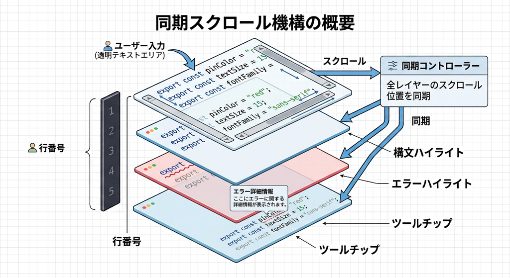

```
JSX
```

```javascript
  const handleJsonScroll = (e) => {
    const scrollTop = e.target.scrollTop;
    const scrollLeft = e.target.scrollLeft;
    if (jsonPreRef.current) {
      jsonPreRef.current.scrollTop = scrollTop;
      jsonPreRef.current.scrollLeft = scrollLeft;
    }
    if (jsonErrorPreRef.current) {
      jsonErrorPreRef.current.scrollTop = scrollTop;
      jsonErrorPreRef.current.scrollLeft = scrollLeft;
    }
    if (jsonLineRef.current) {
      jsonLineRef.current.scrollTop = scrollTop;
    }
    if (jsonTooltipRef.current) {
      jsonTooltipRef.current.scrollTop = scrollTop;
      jsonTooltipRef.current.scrollLeft = scrollLeft;
    }
  };
```

**1**

ユーザーが操作した一番手前の`textarea`の「縦横のスクロール量」を取得する

**2**

色付けを行う背後の`<pre>`要素に対して、取得したスクロール量を全く同じように適用する

**3**

行番号の要素に対しては、縦のスクロールのみを同期させる（横スクロールは不要なため）

#### データの送信処理

「送信」ボタンや「保存」ボタンが押された際、それぞれの入力データをバックエンドへ送信する処理である。思い出データの場合はJSONをパースし、見た目データの場合は正規表現で値を抽出したのち、非同期処理（`fetch`）を用いてサーバーへPOSTリクエストを送信する。データの保存に成功すると、画面のUI状態やブラウザのローカルストレージも同時に更新される。

##### 思い出データの送信（`handleSubmitMemories`関数）

「送信」ボタンが押された際、入力された思い出データ（JSON）をパースし、非同期処理（`fetch`）を用いてバックエンドのAPIへPOSTリクエストを送信する。送信に成功すると、イベント（`memoriesUpdated`）を発火させて画面上のマップのピンを最新の状態に更新する。

```
JSX
```

```javascript
  const handleSubmitMemories = async () => {
    if (memoryError || !memoryCode.trim()) return;

    setIsSubmitting(true);
    try {
      let payload = JSON.parse(memoryCode);

      if (!Array.isArray(payload)) {
        if (payload.MapData && Array.isArray(payload.MapData)) {
          payload = payload.MapData;
        } else {
          payload = [payload];
        }
      }

      payload = payload.map(item => ({
        ...item,
        account_id: userSettings?.id
      }));

      const response = await fetch(`${getApiBaseUrl()}/sakaki-map/api/memories`, {
        method: 'POST',
        headers: {
          'Content-Type': 'application/json',
        },
        body: JSON.stringify(payload),
      });

      if (!response.ok) {
        const errorData = await response.json().catch(() => ({}));
        throw new Error(errorData.error || 'サーバーエラーが発生しました');
      }

      const result = await response.json();
      notifications.show({
        title: '成功',
        message: result.message || '送信に成功しました！',
        color: 'green',
        className: 'glass-notification'
      });
      window.dispatchEvent(new Event('memoriesUpdated'));
    } catch (error) {
      console.error('Submit error:', error);
      notifications.show({
        title: 'エラー',
        message: `送信エラー: ${error.message}`,
        color: 'red',
        className: 'glass-notification'
      });
    } finally {
      setIsSubmitting(false);
    }
  };
```

**1**

入力内容にエラーがある場合や空の場合は、送信処理を行わない

**2**

送信するために、入力されたJSON文字列をJavaScriptのオブジェクトに変換（パース）する

**3**

送信データが配列でない場合、システムが処理しやすいように配列形式に整形する

**4**

送信データに誰が投稿したか識別するための`account_id`を付与する

**5**

サーバーのAPIエンドポイントに対して、POSTメソッドでデータを送信する

**6**

サーバーへの送信が成功した場合、画面上に緑色の成功通知（トースト）を表示する

**7**

思い出データが更新されたことをアプリ全体に通知し、マップのピンを最新状態に再描画させる

##### 表示設定の送信（`handleSaveAppearance`関数）

「保存」ボタンが押された際、正規表現でエディタ内のJavaScriptコードから色やフォントサイズなどの値を抽出する。その後、非同期処理（`fetch`）を用いてサーバーへPOSTリクエストを送信すると同時に、Reactの内部状態（State）やブラウザのローカルストレージも即座に更新することで、設定変更を即座にUIへ反映させている。

```
JSX
```

```javascript
  const handleSaveAppearance = async () => {
    if (appearanceError || appearanceCode.trim() === '') return;
    setIsSavingSettings(true);

    const pinColorMatch = appearanceCode.match(/export\s+const\s+pinColor\s*=\s*"([^"]*)";/);
    const textSizeMatch = appearanceCode.match(/export\s+const\s+textSize\s*=\s*(\d+(\.\d+)?);/);
    const fontFamilyMatch = appearanceCode.match(/export\s+const\s+fontFamily\s*=\s*"([^"]*)";/);

    if (!pinColorMatch || !textSizeMatch || !fontFamilyMatch) {
      setAppearanceError('保存に失敗しました。書き方が間違っています。');
      setIsSavingSettings(false);
      return;
    }

    const newSettings = {
      ...userSettings,
      pinColor: pinColorMatch[1],
      textSize: parseFloat(textSizeMatch[1]),
      fontFamily: fontFamilyMatch[1]
    };

    try {
      // サーバーのアカウント情報を更新
      if (newSettings.id) {
        const payload = [{
          id: newSettings.id,
          username: newSettings.username,
          pinColor: newSettings.pinColor,
          textSize: newSettings.textSize,
          fontFamily: newSettings.fontFamily
        }];
        const response = await fetch(`${getApiBaseUrl()}/sakaki-map/api/accounts`, {
          method: 'POST',
          headers: { 'Content-Type': 'application/json' },
          body: JSON.stringify(payload),
        });
        if (!response.ok) throw new Error('アカウント設定の更新に失敗しました');
      }

      // フロントエンドの状態も更新
      setUserSettings(newSettings);
      localStorage.setItem('sakaki_user_settings', JSON.stringify(newSettings));

      notifications.show({
        title: '保存完了',
        message: '見た目の設定を保存しました。',
        color: 'green',
        className: 'glass-notification'
      });
    } catch (error) {
      notifications.show({
        title: 'エラー',
        message: error.message,
        color: 'red',
        className: 'glass-notification'
      });
    } finally {
      setIsSavingSettings(false);
    }
  };
```

**1**

エディタに書かれたJavaScriptコードの中から、正規表現を用いて値（色、サイズ、フォント名）を抽出する

**2**

抽出した値を用いて、新しい設定データ（`newSettings`）のオブジェクトを作成する

**3**

サーバーへ送信するためのアカウント情報の配列（ペイロード）を作成する

**4**

作成したデータをJSON文字列に変換し、サーバーへPOST送信する

**5**

通信成功後、ReactのState（`userSettings`）を更新し、画面の見た目を即座に切り替える

**6**

更新した設定をブラウザのローカルストレージにも保存し、次回アクセス時にも設定が引き継がれるようにする

#### 描画部分

##### モーダル全体とタブナビゲーション

画面全体をMantineの`Modal`コンポーネントで覆い、その中に`Tabs`コンポーネントを配置して「アカウント情報」「思い出の新規登録」「見た目の編集」の3つの画面を切り替えられるようにしている。

```
JSX
```

```javascript
  return (
    <Modal
      opened={opened}
      onClose={onClose}
      title={<Text size="lg" fw={700} c="white">マイページ</Text>}
      // ...（スタイリング等のプロパティ省略）...
    >
      <Tabs value={activeTab} onChange={handleTabChange} color="blue">
        <Tabs.List px="md" pt="sm">
          <Tabs.Tab value="account" leftSection={<IconUser size={16} />}>アカウント情報</Tabs.Tab>
          <Tabs.Tab value="memory" leftSection={<IconFileCode size={16} />}>思い出の新規登録</Tabs.Tab>
          <Tabs.Tab value="appearance" leftSection={<IconPalette size={16} />}>見た目の編集</Tabs.Tab>
        </Tabs.List>
```

**1**

`opened`の真偽値によって、モーダル画面を表示するか非表示にするかを制御する

**2**

`Tabs`コンポーネントで、現在選択されているタブ（`activeTab`）と、切り替え時の処理（`handleTabChange`）を紐付ける

**3**

各タブのボタン部分を定義し、左側にアイコン（`leftSection`）を配置して視認性を高めている

##### アカウント情報タブ

`userSettings`から取得したユーザー名やIDを表示する。また、「修了証を表示」ボタンを押すと、修了証を表示するための専用のモーダルが開く（`setIsCertModalOpen(true)`）。

```
JSX
```

```javascript
        {/* --- タブ: アカウント情報 --- */}
        <Tabs.Panel value="account" p="xl">
          <Stack gap="md">
            <Box p="md" style={{ backgroundColor: 'rgba(0,0,0,0.2)', borderRadius: '8px' }}>
              <Text c="dimmed" size="sm">ユーザー名</Text>
              <Text c="white" size="lg" fw={700}>{userSettings?.username}</Text>
            </Box>
            {/* ...（中略）... */}
            <Box mt="md" style={{ display: 'flex', justifyContent: 'center' }}>
              <Button variant="light" color="blue" onClick={() => setIsCertModalOpen(true)}>修了証を表示</Button>
            </Box>
          </Stack>
        </Tabs.Panel>
```

**1**

「アカウント情報」タブが選択された時に表示されるパネル（コンテンツ部分）

**2**

`Stack`コンポーネントを利用し、中の要素が均等な間隔で縦に並ぶようにレイアウトする

**3**

オプショナルチェーン（`?.`）を利用し、設定データが存在する場合のみユーザー名を表示する

**4**

ボタンがクリックされた際、修了証モーダルの表示フラグを`true`にする

##### 思い出の新規登録タブ

自作のカスタムエディタ（JSONエディタ）を描画している。ユーザーが操作する透明な`textarea`の背後に、行番号（`jsonLineRef`）、エラー波線（`jsonErrorPreRef`）、色付けされたコード（`jsonPreRef`）、ヘルプツールチップ（`jsonTooltipRef`）のレイヤーが重なっている。入力内容のバリデーション処理はJSONの構文チェックを、ボタンクリック時の処理は思い出データの送信を利用している。

```
JSX
```

```javascript
        {/* --- タブ: 思い出の新規登録 --- */}
        <Tabs.Panel value="memory">
          <Box p="md" style={{ display: 'flex', flexDirection: 'column', gap: '16px', height: '100%' }}>
            {/* カスタムエディタのレイヤー構成 */}
            <Box style={{ flex: 1, display: 'flex', position: 'relative' }}>

              {/* 行番号 */}
              <Box ref={jsonLineRef} style={{ /* ... */ }}>
                {memoryCode.split('\n').map((_, i) => (<div key={i}>{i + 1}</div>))}
              </Box>

              {/* エディタ部分（重なるレイヤー） */}
              <Box style={{ position: 'relative', flex: 1, overflow: 'hidden' }}>
                <textarea /* 手前の透明な入力欄 */ />
                <pre ref={jsonErrorPreRef} /* エラー波線のレイヤー */ />
                <pre ref={jsonPreRef} /* 色付けコードのレイヤー */ />
                <pre ref={jsonTooltipRef} /* ツールチップのレイヤー */ />
              </Box>
            </Box>

            <Group justify="space-between">
              <Button onClick={handleResetMemory}>リセット</Button>
              <Button onClick={handleSubmitMemories}>送信</Button>
            </Group>
          </Box>
        </Tabs.Panel>
```

**1**

行番号とエディタ本体を横並びに配置するためのコンテナ

**2**

入力されたコードを改行で分割し、その行数分だけ行番号を描画する

**3**

ユーザーが実際に文字を入力・編集するためのテキストエリア（透明にして前面に配置）

**4**

色付けやエラー波線などを行うレイヤー群。`textarea`の背後に重ねられている

**5**

入力されたJSONデータをサーバーへ送信するためのボタン

##### 見た目の編集タブ

「思い出の新規登録」タブと同じくカスタムエディタを描画しているが、こちらはJavaScript用のエディタとなっている。背後のツールチップレイヤー（`jsTooltipRef`）には、各設定項目（`pinColor`、`textSize`、`fontFamily`）に対応する専用のヘルプ文が用意されている。入力内容のバリデーション処理はJavaScriptの構文チェックを、ボタンクリック時の処理は表示設定の送信を利用している。

```
JSX
```

```javascript
        {/* --- タブ: 見た目の編集 --- */}
        <Tabs.Panel value="appearance">
          <Box p="md" style={{ display: 'flex', flexDirection: 'column', gap: '16px', height: '100%' }}>
            {/* カスタムエディタのレイヤー構成 */}
            <Box style={{ flex: 1, display: 'flex', position: 'relative' }}>

              {/* 行番号 */}
              <Box ref={jsLineRef} style={{ /* ... */ }}>
                {(appearanceCode || ' ').split('\n').map((_, i) => (<div key={i}>{i + 1}</div>))}
              </Box>

              {/* エディタ部分（重なるレイヤー） */}
              <Box style={{ position: 'relative', flex: 1, overflow: 'hidden' }}>
                <textarea /* 手前の透明な入力欄 */ />
                <pre ref={jsErrorPreRef} /* エラー波線のレイヤー */ />
                <pre ref={jsPreRef} /* 色付けコードのレイヤー */ />
                <pre ref={jsTooltipRef} /* ヘルプ文のレイヤー（JS用） */ />
              </Box>
            </Box>

            <Group justify="space-between">
              <Button onClick={handleResetAppearance}>リセット</Button>
              <Button onClick={handleSaveAppearance}>保存</Button>
            </Group>
          </Box>
        </Tabs.Panel>
      </Tabs>
```

**1**

JavaScriptコードの行数に合わせて、左側に表示する行番号を描画する

**2**

親要素からはみ出した部分を隠す（`overflow: hidden`）ことで、綺麗なエディタ枠を保つ

**3**

構文エラーがあった際に、該当する行の背後に赤い波線を表示させるための専用レイヤー

**4**

「リセット」ボタンと「保存」ボタンを、左右の端に寄せて均等に配置する

##### 修了証モーダル

アカウント情報タブで「修了証を表示」ボタンが押された際に手前に浮かび上がる専用のモーダルである。`containerType: 'inline-size'` を用いたコンテナクエリを活用し、画面サイズに関わらず縦横比（2911:4117）を維持したまま、フォントサイズ（`cqw`）も自動でレスポンシブに調整される仕組みになっている。

修了証プレビュー画面

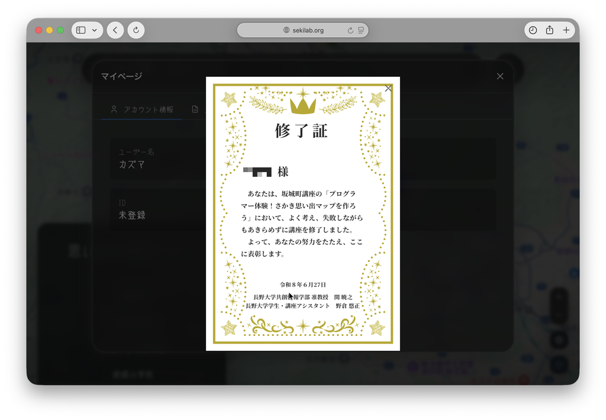

```
JSX
```

```javascript
      <Modal
        opened={isCertModalOpen}
        onClose={() => setIsCertModalOpen(false)}
        size="xl"
        centered
        // ...（スタイリング省略）...
      >
        <Box style={{
          position: 'relative',
          width: '100%',
          aspectRatio: '2911 / 4117',
          backgroundImage: `url(${certificateBg})`,
          backgroundSize: '100% 100%',
          containerType: 'inline-size' // コンテナクエリでレスポンシブ対応
        }}>
          {/* 中身のテキスト（cqwを用いて自動リサイズ） */}
          <Box style={{ position: 'absolute', top: '15%', left: '18%', right: '18%', bottom: '15%', display: 'flex', flexDirection: 'column' }}>
            <div style={{ fontSize: '7cqw', textAlign: 'center', fontWeight: 'bold' }}>修了証</div>

            <div>
              <div style={{ fontSize: '5cqw', marginBottom: '4cqw' }}>{userSettings?.username || 'ゲスト'} 様</div>
              {/* ...（表彰文省略）... */}
            </div>
            {/* ...（署名省略）... */}
          </Box>
        </Box>
      </Modal>
    </Modal>
  );
```

**1**

修了証モーダルの表示フラグが`true`の時に画面手前に表示される

**2**

モーダルの基本サイズを特大（Extra Large）に設定し、証書を大きく表示する

**3**

画面の中央にモーダルが配置されるよう指定する

**4**

修了証の背景画像のピクセルサイズに基づく縦横比（2911:4117）を維持するよう指定

**5**

コンテナクエリを有効化し、この要素の幅を基準として内部のフォントサイズなどを相対的に計算できるようにする

**6**

背景画像の枠組みに合わせて、テキストを配置する絶対領域を指定する

**7**

コンテナの幅（`100cqw`）に対する割合で文字の大きさを指定し、画面幅が変わっても比率が崩れないようにする

### 1.3.3 実装の確認

[ここ](https://www.sekilab.org/sakaki-map/) から確認できる。

# 2 第15回

## 2.1 ネイティブアプリへの変更の可用性の再調査・検討

### 2.1.1 アンケート結果の再考

[第11回](https://yumachin2003.github.io/docs/zemi26/11#アンケート結果より) での社会実装からの課題の抽出は、アンケート作成に時間が取れず、内容として薄いものになってしまったため、結果的に回答を拡大解釈せざるをえない状況となっていた。

そのため、改めてアンケートを見直し、現状の回答から考えられる結果を整理した。

##### ① アンケートから見えたユーザーの隠れたニーズ

今回のプログラマー体験講座において、参加した子どもたちは地図の閲覧や基本操作に対して高い理解を示した。しかし、自由記述欄からは以下のような「受動的なマップ操作」に対する物足りなさと、「より能動的な体験」への強い興味が浮かび上がった。

課題の芽（素朴な疑問）:

> 「マップをしるしたりする以外になにができるのか」

興味の方向性（能動的なアクションへの欲求）:

> 「ゲームの作り方の講座を受けたい」

> 「ユニティ（Unity）をやってみたい」

これらの声は、単にお祭りや地域の情報を「地図上で見る」「ピンを立てて記録する」だけの一方通行な機能（静的なマップ機能）だけでは、ユーザーが飽きてしまい、継続的な利用（エンゲージメント）に繋がりにくいという現状の限界を示している。

##### ② 現状システムの評価と課題の抽出

坂城町講座での社会実装では、ボタン配置やメニューなどの基本的な操作性について「わかりやすい」と好評だった。

一方で、「マップにしるしをつける以外に何ができるのか」という疑問の声も挙がった。

これは、現状の「地図上に情報を記録する」だけの機能では、ユーザーが使い続けるモチベーションを保てないという課題を示している。

##### ③ 課題に対する仮説と解決へのアプローチ

この課題に対して、単に便利機能を増やすだけでは根本的な解決にはならない。

「お祭りを歩き回って継続的にアプリを使ってもらう（歩数の増加）」ためには、マップに印をつける行為自体をもっと面白くする必要がある。

もし、自分が残した記録を他の人と共有したりリアクションを送り合えるSNS的な仕組みがあれば、「単なる記録」が「体験の共有」に変わり、自発的にアプリを使い続けてもらえるのではないかと考えた。

##### ④ 解決策としてのシステム要件とネイティブアプリ化（SwiftUI）の採用

上記の仮説に基づき、マップ機能に体験の共有機能を追加することにした。

しかし、お祭り会場を歩きながら即座に写真を撮ったり位置情報を取得したりするには、現在のWebアプリ（ブラウザ）ではカメラの起動速度や動作の軽快さに限界がある。

そのため、スマートフォンのカメラやGPS機能をスムーズに扱える「SwiftUI」を用いて、iOSネイティブアプリとしてシステムを作り直すことが、今回の課題を解決するための最適な方法だと判断した。

### 2.1.2 アンケートの補填

上の考察を元にし、さらにアンケートの回答を充実させるため、地域づくり総合センターの方にお願いし、保護者へオンデマンドアクセスを可能となった旨のメールと共に、[Google Formで作成したアンケート](https://forms.gle/PcC6gjcoQSYFX3ob7) を送信してもらった。

##### アンケート内容

**システムの操作感について（保護者のみ）**

- 地図の使用感はどうか
- メニューやボタンの配置はどうか
- その他、改善すべき点

**お気に入りスポットやイベントのシェアについて**

- 普段の生活で「ここの場所、面白かったな」「綺麗だな」と思ったときにやること
  - 写真を撮って、自分のスマホに保存する
  - 日記やノート（紙媒体でもスマホなど電子媒体でも）に記録する
  - あとで友達や家族と直接会って、写真を見せたり話したりする
  - 直接会ってではなく、SNS（LINEやInstagramなど）で友達に送ったりシェアしたりする
  - その他
- 知り合いに「おすすめの場所」を教えたいとき、または友達から教わるときに、困った経験
  - 言葉や写真だけだと、どこにあるか（場所）が分かりにくい
  - LINEなどで教わっても、あとからメッセージを探すのが大変
  - 行ってみたいと思うが、結局忘れてしまう
  - その他
- 休日にお出かけするときや、友達と遊ぶ場所を決めるときにあると嬉しい情報
  - 友達が最近行って面白かった場所
  - 今いる場所のすぐ近くで遊べる場所
  - テレビやネット、SNSで話題になっている場所
  - 入場料や営業時間などの基本情報
  - その他

##### 送信してもらったメールの内容

> 保護者 様

> 先日は、坂城町講座にご参加頂き、誠にありがとうございました。 遅ればせながら、プログラミング教室で実際に使用した「さかき思い出マップ」が、ご自宅の端末からもご覧いただけるようになりましたのでお知らせいたします。 以下のリンクからアクセスいただけます。 https://www.sekilab.org/sakaki-map/

> ページアクセス後、右上の👤ログインボタンからログインしていただくことにより、プログラミング教室で実際にカスタマイズしたテーマ設定（ピンの色・文字サイズ・フォント）を画面に反映することができます。

> 【ログイン情報】 ユーザー名: パスワード:

> また、ログインボタンからマイページを開くいていただくと、思い出の追加やテーマの変更を、教室と同じようにテキストベースで変更することが可能になっております。こちらはご自宅のPCやスマートフォンなどのブラウザからご利用いただけます。ぜひ、お子様と一緒に教室の振り返りとしてご活用いただけますと幸いです。

> 並びに、保護者様へ一つお願いがございます。 今回の教室で使用したWebアプリは、アシスタント学生の野倉がゼミの活動にて開発したシステムを利用したものとなっております。システムのさらなる改善を目指し、当日はお子様にもアンケートをお願いいたしましたが、時間が限られており十分なご回答をお伺いすることができませんでした。つきましては、保護者様も一度「さかき思い出マップ」を触っていただき、改めて使用感や改善点などについて率直なご感想をお聞かせいただけないでしょうか。 以下からアンケートにご回答ください。 https://forms.gle/PcC6gjcoQSYFX3ob7

> お忙しいところ大変恐縮ですが、ご協力を賜りますようお願い申し上げます。

送信していただいたのは7/22で、7/27現在回答は1件もいただけていない状況のため、夏休み明けのゼミにて経過を報告する。

## 2.2 証明書切れの対応（応急処置）

[第02・03回](https://yumachin2003.github.io/docs/zemi26/02_03)で生成した証明書の期限か切れてしまい、ページを開く時に警告画面が再度表示されるようになってしまった。ワイルドカード証明書の取得にはDNS-01チャレンジが必須であり、DNSにレコードを追加する必要がある。そのため、応急処置で`www.sekilab.org`のみ証明書をHTTP-01チャレンジで発行した。

```
bash
```

```bash
apptainer run   \
  -B ~/certbot/etc:/etc/letsencrypt \
  -B ~/certbot/lib:/var/lib/letsencrypt \
  -B ~/certbot/log:/var/log/letsencrypt \
  -B /var/www/html:/var/www/html \
  docker://certbot/certbot:latest \
  certonly --webroot -w /var/www/html -d www.sekilab.org
```

**1**

ホスト側のCertbot設定ディレクトリをマウント（発行された証明書の保存先）

**2**

ホスト側のCertbot作業ディレクトリをマウント

**3**

ホスト側のCertbotログディレクトリをマウント

**4**

Apacheのドキュメントルートをマウント（ACMEチャレンジ用の認証ファイル配置先）

**5**

Docker HubからCertbotの公式イメージを取得してコンテナとして実行

**6**

Webrootプラグインを利用し、`www.sekilab.org` の証明書のみ（`certonly`）を発行

## 2.3 洋書の選定

本学習における最初の教材として、数ある技術書の中から比較検討を行った結果、[『Thinking in SwiftUI』](https://www.objc.io/books/thinking-in-swiftui/)（objc.io 刊）を選定した。

Thinking in SwiftUI

[figure not shown]

### 2.3.1 選定理由

本書を選定した主な理由は以下の3点である。

1. **Reactでの開発経験の活用**

   SwiftUIが採用する宣言的UI（Declarative UI）の概念は、これまで経験してきたReactと多くの共通点を持つ。そのため、Reactにおける「状態からUIが構築される」というメンタルモデルを、そのままSwiftUIの学習へと応用できると考えたためである。
2. **フレームワークの本質的な理解**

   単なるコードの書き方にとどまらず、「状態（State）の変化がいかにしてUIの更新に繋がるのか」「アプリケーション内でデータがどのように循環するのか」といった、フレームワークの背後にあるアーキテクチャに焦点を当てて解説されている。
3. **限られた期間での学習効率**

   本書は全体で約170ページと非常にコンパクトにまとまっている。夏期休暇という限られた時間、また一人で輪読しなければいけないという状況の中で、SwiftUIのコアとなる概念を網羅的かつ迅速にインプットする上で、最も費用対効果が高いと判断した。

### 2.3.2 比較検討したその他の候補書籍

選定の過程において比較検討した他の洋書の概要および評価を以下の表にまとめる。これらについては初期の通読用としては見送ったものの、今後の開発フェーズにおいて特定の機能を実装する際の「リファレンス（辞書）」として適宜活用していく予定である。

| 書籍名 | ページ数 | 概要 | 評価 |
| --- | --- | --- | --- |
| **[SwiftUI Cookbook (第3版)](https://www.packtpub.com/en-jp/product/swiftui-cookbook-9781805125369)** | 約798ページ | 実装上の具体的な課題に対する解決策を網羅したレシピ集。 | MapKitを利用した地図機能の統合やFirebaseとの連携など、具体的な機能を実装するフェーズにおいて、逆引き辞典として非常に有用である。 |
| **[SwiftUI by Tutorials (第5版)](https://www.kodeco.com/books/swiftui-by-tutorials)** | 約748ページ | 実際にアプリケーションを構築しながら学ぶチュートリアル形式の技術書。 | 複数のコンポーネントを組み合わせてアプリ全体を構築する実践的なスキルの習得には適している。しかし、分量が大きいため、「概念を最速で把握する」という初期段階の目的には合致しなかった。 |
| **[UI Design for iOS App Development](https://link.springer.com/book/10.1007/978-1-4842-6640-3)** | 約322ページ | SwiftUIを用いたUI/UXの構築手法と、デザインの原則に焦点を当てた書籍。 | アプリケーションの視覚的な洗練や操作感の向上を図る段階において有効である。現段階では機能的なプロトタイプの動作確認を優先するため、初期段階での優先度は低いと判断した。 |
| **[SwiftUI Views Mastery](https://www.bigmountainstudio.com/swiftui-views-mastery)** | 計約1000ページ （2分冊） | SwiftUIで提供されている全UIコンポーネントを視覚的にまとめたリファレンス本。 | Apple公式ドキュメント以上に直感的なUI辞書として機能する。特定の画面レイアウトの構築や装飾において有用な補助ツールとなり得る。 |